# Assessment of *Ascochyta rabiei* Disease Symptoms Using Machine Learning Image Analysis

Chetan Reval and Ido Bar

09 June 2022

## Introduction

*Ascochyta rabiei* is a necrotrophic fungus, causing the Ascochyta blight disease on chickpea, a disease that can cause substantial damage to crops and reduce yield and profits. The disease poses a major risk to the chickpea industry in Australia and worldwide and therefore significant efforts are invested to better understand and monitor the population of *A. rabiei* and identify the most aggressive isolates that are then used to screen breeding material to develop more resistant (or less susceptible) varieties.

The aggressiveness level of *A. rabiei* is determined by assessing the disease symptoms on a differential set of host chickpea varieties/genotypes, in a process that is termed “phenotyping”. The Plant Pathology team at the Sustainable Food Production group at Griffith University (led by [Prof Rebecca Ford](https://experts.griffith.edu.au/18969-rebecca-ford) and [Dr Ido Bar](https://experts.griffith.edu.au/8327-ido-bar)) are preforming those assessments annually on a collection of *A. rabiei* isolates collected from the chickpea growing regions in Australia each year. The assessment is performed on 5 weeks old chickpea seedlings that have been inoculated with *A. rabiei* isolates and grown in controlled environment conditions that are conducive for the fungus to establish itself and cause disease on the plants. The exact phenotyping methods are described in (Mehmood *et al.* 2017; Sambasivam *et al.* 2020)

### Aims

- Review machine-learning methods and approaches that can be applied to automatically assess disease symptoms from captured imaged
- Apply and optimise selected methods and assess their accuracy, efficiency and correlation with traditional plant pathology visual assessment method

## Methods

### Experimental Design

Disease assessment bioassays were managed and performed by a trained plant pathologist (Melody Christie). Each bioassay included 6 *A. rabiei* isolates which were used to inoculate 5 differential chickpea host genotypes. The assays were performed in a blinded replicated design, where each isolate-host combination was replicated in 2 pots, each containing 5 chickpea seedlings. The seedlings were inoculated at 3 weeks after germination and were assessed 2 weeks post inoculation.

The assessment was then performed for each plant in each pot and the leaf and stem disease scores were assessed (on a qualitative ordinal 1-9 scale), as well as the percentage of the diseased area (Mehmood *et al.* 2017; Sambasivam *et al.* 2020). The disease assessment scores were recorded on a tablet using an online form. An example of a pot with chickpea seedlings infected with Ascochyta blight prior to assessment can be seen in Figure 1 below.

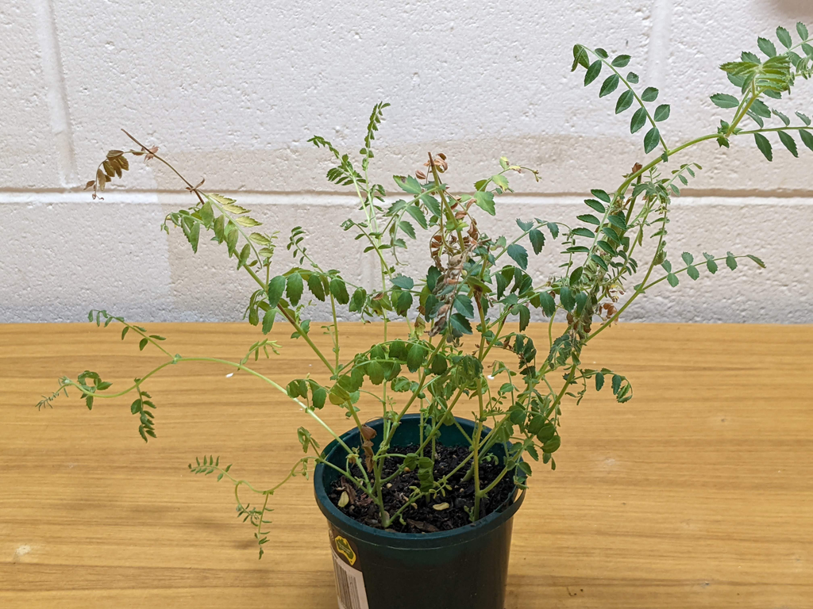

Figure 1: Chickpea seedlings affected by *Ascochyta rabiei*

```r
knitr::include_graphics("input_images/infected_plant_in pot.jpg")
```

### Image Capture

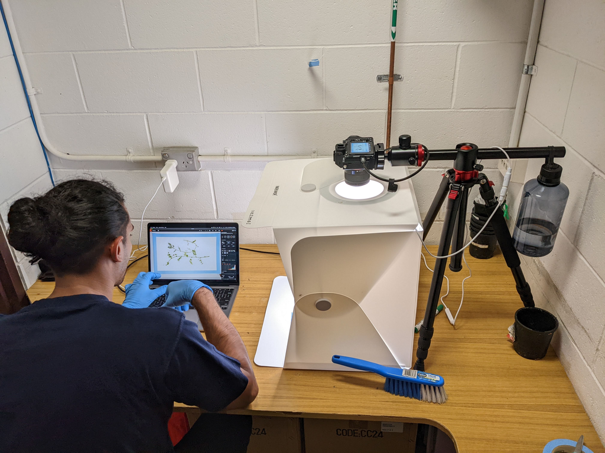

Figure 2: Image capture setup for disease assessment of *Ascochyta rabiei*

```r
knitr::include_graphics("input_images/image_capture_setup.jpg")
```

### Image Processing for Disease Assessment

Image analysis and data processing and visualisation were performed in the R version 4.1.0 (2021-05-18) statistical computing environment (R Core Team 2017; Ihaka and Gentleman 1996). Specifically, various packages from the [tidyverse](https://www.tidyverse.org/) collection were used for general data import, wrangling, summary and visualisation and [janitor](http://sfirke.github.io/janitor/) was used for data cleansing and sanitising (Wickham *et al.* 2019; Firke 2021). The [magick](https://docs.ropensci.org/magick/) and [pliman](https://tiagoolivoto.github.io/pliman/index.html) R packages were used for image analysis and automatic disease assessment (Ooms 2021; Olivoto 2022). The [furrr](https://furrr.futureverse.org/) package was used to process the images in parallel along with [tictoc](https://collectivemedia.github.io/tictoc/) to measure and evaluate processing times (Izrailev 2021; Vaughan and Dancho 2022).

```r
# install/load packages in one-liner
library(pacman)
# load/install from GitHub repos
p_load_gh(char = c("TiagoOlivoto/pliman",
                   "DavisVaughan/furrr",
                   "HenrikBengtsson/progressr"))
# load/install from CRAN/BioConductor
p_load(tidyverse, magick, tictoc, Microsoft365R, janitor, ISOweek)
```

#### Overview:

1. Cropping
2. Background removal
3. Disease assessment using pliman
4. Return results as a table with the image-based assessment for each plant in each pot

### Evaluation of Image-based Assessments

The visual pathology assessment data was downloaded directly from the SharePoint site capturing the online form submissions using Microsoft365R R package (Ooi 2021). The data was merged with the bioassay design spreadsheet to assign an isolate-host combination for each pot.

## General information

This document was last updated at 2022-06-09 08:30:06 using R Markdown (built with R version 4.1.0 (2021-05-18)). Markdown is a simple formatting syntax for authoring HTML, PDF, and MS Word documents. It is especially powerful at authoring dynamic documents and reports which can showcase and execute code chunks and use the results in the output. For more details on using R Markdown see http://rmarkdown.rstudio.com and [Rmarkdown cheatsheet](https://www.rstudio.com/wp-content/uploads/2016/03/rmarkdown-cheatsheet-2.0.pdf).

## Bibliography

Firke S (2021) Janitor: Simple tools for examining and cleaning dirty data.

Ihaka R, Gentleman R (1996) R: A language for data analysis and graphics. Journal of Computational and Graphical Statistics 5:299–314. doi: 10.1080/10618600.1996.10474713

Izrailev S (2021) Tictoc: Functions for timing r scripts, as well as implementations of stack and list structures.

Mehmood Y, Sambasivam P, Kaur S, et al. (2017) Evidence and Consequence of a Highly Adapted Clonal Haplotype within the Australian *Ascochyta rabiei* Population. Frontiers in Plant Science 8:

Olivoto T (2022) Lights, camera, pliman! An R package for plant image analysis. Methods in Ecology and Evolution 13:789–798. doi: 10.1111/2041-210X.13803

Ooi H (2021) Microsoft365R: Interface to the ’microsoft 365’ suite of cloud services.

Ooms J (2021) Magick: Advanced graphics and image-processing in r.

R Core Team (2017) R: A Language and Environment for Statistical Computing. R Foundation for Statistical Computing, Vienna, Austria

Sambasivam P, Mehmood Y, Bar I, et al. (2020) Evidence of recent increased pathogenicity within the Australian *Ascochyta rabiei* population. bioRxiv 2020.06.28.175653. doi: 10.1101/2020.06.28.175653

Vaughan D, Dancho M (2022) Furrr: Apply mapping functions in parallel using futures.

Wickham H, Averick M, Bryan J, et al. (2019) Welcome to the tidyverse. Journal of Open Source Software 4:1686. doi: 10.21105/joss.01686